# `pyCactus` Demo

This notebook demonstrates basic functions of the `pyCactus` post-processing module.

Phillip Chiu, September 16, 2014. Wind Energy Technologies, Sandia National Labs

### Contents

- Specifying data files
- Creating a `CactusRun` instance
- Using the `CactusRun` Class
  - Accessing time, element, revolution data
  - *Wake Data:*
    - Extracting wake data to NumPy arrays
    - Writing the wake element data to VTK file
    - Time series at a specific location on the Cartesian grid
    - Field averaging

```python
%load_ext autoreload
%autoreload 2

# paths
PYCACTUS_PATH = '/ascldap/users/pchiu/SDSS/repos/DAK-CACTUS/postprocessing/pyCactus/'
import os

import sys
import numpy as np
import matplotlib.pyplot as plt
import matplotlib.cm as cm
import pandas as pd
import time

sys.path.append(PYCACTUS_PATH)
import pyCactus
```

## Specifying data files

```python
case_name  = 'hawt'
run_dir    = '/ascldap/users/pchiu/Local/run_data/15/'
```

## Creating a CactusRun instance

The CactusRun class stores information about a single run. It can be instantiated as follows:

```python
tic = time.time()
geom_fname = 'design_A_aiaa.geom'
run = pyCactus.CactusRun(run_dir, case_name, geom_fname=geom_fname)
print 'Time to instantiante CactusRun class: %2.2f s' % (time.time() - tic)
```

```
Loaded wake element data in 0.36 s
Loaded wake grid data in 6.03 s
Success: Loaded case `hawt` from path `/ascldap/users/pchiu/Local/run_data/15/`

Time to instantiante CactusRun class: 8.14 s
```

## Using the CactusRun class

On instantiation, the CactusRun class loads the geometry file along with the time, element, and revolution data. It also parses the first line of each of the wake grid and wake node `.csv` files to determine the output times. Note that the module currently requires that the wake grid and node files be formatted into one `.csv` per timestep.

The time, element, and revolution data are stored as Pandas dataframes. In order to reduce the time for class instantiation, data is only read from files in to memory when needed.

### Accessing time, element, revolution data

Time, element, and revolution data can be accessed using the appropriate variables names:

- `CactusRun.time_data`
- `CactusRun.elem_data`
- `CactusRun.rev_data`

Each returns a Pandas dataframe.

```python
tic = time.time()
run.elem_data
print 'Time to load (first time) %2.5f s' % (time.time()-tic)

tic = time.time()
run.elem_data
print 'Time to load (second time) %2.5f s' % (time.time()-tic)

run.elem_data.head()
```

```
Time to load (first time) 1.48457 s
Time to load (second time) 0.00016 s
```

|  | Normalized Time (-) | Theta (rad) | Blade | Element | Rev | x/R (-) | y/R (-) | z/R (-) | AOA25 (deg) | AOA50 (deg) | ... | CL (-) | CD (-) | CM25 (-) | CLCirc (-) | CN (-) | CT (-) | Fx (-) | Fy (-) | Fz (-) | te (-) |
| --- | --- | --- | --- | --- | --- | --- | --- | --- | --- | --- | --- | --- | --- | --- | --- | --- | --- | --- | --- | --- | --- |
| 0 | 0 | 0 | 1 | 1 | 1 | 0 | 0.037972 | -0.010069 | 46.49784 | 46.49784 | ... | 0.671317 | 0.35 | -0.0001 | 0.0001 | 0.715994 | -0.246005 | 0.000015 | -0 | 0.000014 | 0.000001 |
| 1 | 0 | 0 | 1 | 2 | 1 | 0 | 0.041973 | -0.010069 | 44.68286 | 44.68286 | ... | 0.659498 | 0.35 | -0.0001 | 0.0001 | 0.715023 | -0.214894 | 0.000051 | -0 | 0.000045 | 0.000002 |
| 2 | 0 | 0 | 1 | 3 | 1 | 0 | 0.049806 | -0.010069 | 41.25927 | 41.25927 | ... | 0.593653 | 0.35 | -0.0001 | 0.0001 | 0.677083 | -0.128388 | 0.000083 | -0 | 0.000059 | 0.000003 |
| 3 | 0 | 0 | 1 | 4 | 1 | 0 | 0.061141 | -0.010069 | 36.62650 | 36.62650 | ... | 0.505568 | 0.35 | -0.0001 | 0.0001 | 0.614548 | -0.020730 | 0.000122 | -0 | 0.000061 | 0.000004 |
| 4 | 0 | 0 | 1 | 5 | 1 | 0 | 0.076026 | -0.010069 | 31.10437 | 31.10437 | ... | 0.410636 | 0.35 | -0.0001 | 0.0001 | 0.532408 | 0.087546 | 0.000167 | 0 | 0.000046 | 0.000003 |

5 rows × 29 columns

### Accessing wake data

Due to their large file sizes, wake element and grid data are accessed differently than the others -- the entire data file is never loaded into memory.

```python
print 'wakeelems.num_times:', run.wakeelems.num_times
print ''
print 'wakeelems.times[0:10]:\n\t',run.wakeelems.times[0:10]
print ''
print ''
print 'wakegrid.num_times:', run.wakeelems.num_times
print ''
print 'wakegrid.times[0:10]:\n\t',run.wakeelems.times[0:10]
```

```
wakeelems.num_times: 320

wakeelems.times[0:10]:
	[ 0.         0.3490659  0.6981317  1.047198   1.396263   1.745329   2.094395
  2.443461   2.792527   3.141593 ]


wakegrid.num_times: 320

wakegrid.times[0:10]:
	[ 0.         0.3490659  0.6981317  1.047198   1.396263   1.745329   2.094395
  2.443461   2.792527   3.141593 ]
```

### Extracting wake data to NumPy arrays

A dataframe containing data at a particular timestep can be extracted using the function `get_df_inst()`. This dataframe can be interpreted using the functions `wakedata_from_df()` and `wakegriddata_from_df()`. These functions are prototyped below.

```
data_arrays, has_node_ids = wakedata_from_df(time)
data_arrays, grid_dims    = wakegriddata_from_df(time)
```

In both cases, `data_arrays` is a dictionary containing variables names as keys, while the values of the dictionary are NumPy arrays.

```python
# Get dataframe for t = 0.3490659
wake_df_inst = run.wakeelems.get_df_inst(time=0.3490659)
wake_df_inst.head()

# extract variables
wakedata, has_node_ids = run.wakeelems.wakedata_from_df(wake_df_inst)
```

```python
# Get dataframe for t = 0.3490659
wakegrid_df_inst = run.wakegrid.get_df_inst(time=0.3490659)
wakegrid_df_inst.head()

# extract variables
wakegriddata, wakegriddims = run.wakegrid.wakegriddata_from_df(wakegrid_df_inst)
```

The variables names can be viewed by printing the dictionary keys. The variable values can be extracted using the standard syntax, e.g.,

```python
u = wakedata['u']
```

```python
print 'Wake Node Variables: ', wakedata.keys()
print 'Wake Node `has_node_ids`: ', has_node_ids
print ''
print 'Wake Grid Variables: ', wakegriddata.keys()
print 'Wake Grid Dimensions: ', wakegriddims.keys()
```

```
Wake Node Variables:  ['node_ids', 'elems', 'u', 'w', 'v', 'y', 'x', 'z']
Wake Node `has_node_ids`:  True

Wake Grid Variables:  ['Ufs', 'Wfs', 'U', 'W', 'V', 'Y', 'X', 'Z', 'Vfs']
Wake Grid Dimensions:  ['nx', 'ny', 'nz', 'dz', 'xlim', 'dx', 'dy', 'zlim', 'ylim']
```

### Writing the wake element data to VTK files

The wake data can also be written to a VTK file to facilitate post-processing with ParaView using the `write_vtk_series()` functions. These functions will write a series of VTK files, and a .pvd collection file which can be read into ParaView directly as a time series.

```python
wakenode_output_path = '/ascldap/users/pchiu/Local/viz/'
wakegrid_output_path = '/ascldap/users/pchiu/Local/viz/'
#run.wakeelems.write_vtk_series(wakenode_output_path, 'wakenode_name')
#run.wakegrid.write_vtk_series(wakegrid_output_path, 'wakegrid_name')
```

### Time series at a specific location on the Cartesian grid

Data at a specific location can be extracted. Note that this function takes some time, since it must loop through all the data files.

```python
# enter a list of point coordinates
point_list = [(0.0, 0.0, 0.0), (1.0, 0.0, 0.0)]

tic = time.time()
timeseries_dict = run.wakegrid.pointdata_time_series(point_list, ti_start=0, ti_end=-1)
print 'Time to produce series: %2.2f s' % (time.time() - tic)
```

```
Time to produce series: 63.39 s
```

```python
# extract the data
t   = timeseries_dict['t']
u   = timeseries_dict['u']
v   = timeseries_dict['v']
w   = timeseries_dict['w']
ufs = timeseries_dict['ufs']
vfs = timeseries_dict['vfs']
wfs = timeseries_dict['wfs']
```

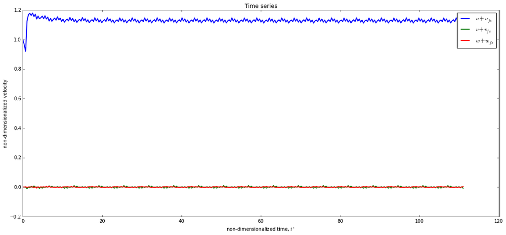

```python
# plot the data at the first point
point_id = 1
plt.figure(figsize=(15,7))
plt.plot(t, u[point_id,:]+ufs[point_id,:], label='$u + u_{fs}$', lw=2)
plt.plot(t, v[point_id,:]+vfs[point_id,:], label='$v + v_{fs}$', lw=2)
plt.plot(t, w[point_id,:]+wfs[point_id,:], label='$w + w_{fs}$', lw=2)

plt.title('Time series')
plt.xlabel('non-dimensionalized time, $t^*$')
plt.ylabel('non-dimensionalized velocity')
plt.legend()

plt.tight_layout()
plt.show()
```

### Field averaging

We can compute field averages of Cartesian grid data using the `field_time_average()` function.

```python
tic = time.time()
data_dict_mean = run.wakegrid.field_time_average(ti_start=-5, ti_end=-1)
print 'Time to average fields: %2.2f s' % (time.time() - tic)
```

```
Time to average fields: 0.72 s
```

```
Times averaged:  [ 109.9557  110.3048  110.6539  111.0029]
```

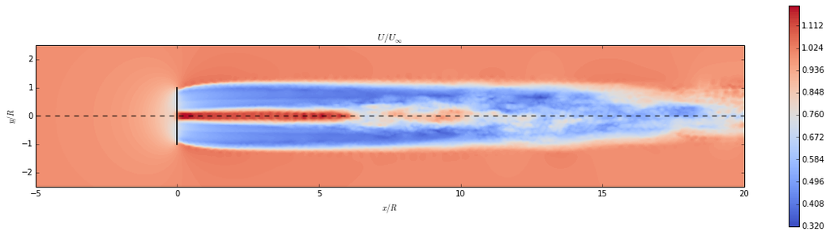

```python
# Get the data
print 'Times averaged: ', data_dict_mean['t']
X   = data_dict_mean['X']
Y   = data_dict_mean['Y']
Z   = data_dict_mean['Z']
U   = data_dict_mean['U']
V   = data_dict_mean['V']
W   = data_dict_mean['W']
Ufs = data_dict_mean['Ufs']
Vfs = data_dict_mean['Vfs']
Wfs = data_dict_mean['Wfs']

# Reshape to 2D
ny = run.wakegrid.ny
nx = run.wakegrid.nx

X   = np.reshape(X, [ny, nx])
Y   = np.reshape(Y, [ny, nx])
Z   = np.reshape(Z, [ny, nx])
U   = np.reshape(U, [ny, nx])
V   = np.reshape(V, [ny, nx])
W   = np.reshape(W, [ny, nx])
Ufs = np.reshape(Ufs, [ny, nx])
Vfs = np.reshape(Vfs, [ny, nx])
Wfs = np.reshape(Wfs, [ny, nx])

# u
plt.figure(figsize=(20,5))
plt.contourf(X,Y,U+Ufs,128,cmap=cm.coolwarm)
plt.colorbar()
plt.axis('image')
plt.title('$U/U_{\infty}$')
plt.xlabel('$x/R$')
plt.ylabel('$y/R$')
plt.plot([0,0],[-1.0,1.0], linewidth='2', color='black') # plot rotor disc
plt.plot([-5.0,25.0],[0,0], linestyle='--', linewidth='1', color='black') # plot centerline

plt.show()
```